# TFG — Statistical Analysis

## Methodology

The following questionnaires have been applied to the participating students:

- RNPQ ([Reliability and Pain Knowledge Questionnaire](https://psycnet.apa.org/doiLanding?doi=10.1037%2Ft77106-000)). Questionnaire with 12 questions with three possible answers (True, False, Undecided). 1 point is scored for each correct answer and 0 points for each incorrect answer or “Undecided”. The total score ranges from 0 to 12 points, with higher scores indicating greater knowledge about pain.
- HC-PAIRS ([Health care providers’ attitudes and beliefs about functional impairments and chronic back pain](https://pubmed.ncbi.nlm.nih.gov/8788576/)). Questionnaire with 15 questions with 7 possible answers on a Likert scale (from Totally Disagree to Totally Agree). It is scored from 1 to 7 points. The total score ranges from 15 to 105, with lower scores indicating more helpful pain attitudes.

```r
# Packages loading.
library(tidyverse)
library(knitr)
library(broom)
library(vtable)
library(tidymodels)
library(ggpubr)
library(car)
library(rstatix)
```

```r
# Data loading.
df <- read_csv("datos/datos-2024-04-22.csv") |>
    # Select the variables of interest.
    select(Degree, Course, Gender, RNPQ, HC_PAIRS, starts_with("X"), starts_with("Y")) |>
    # Convert the categorical variables to factors.
    mutate(Degree = factor(Degree), Course = factor(Course), Gender = factor(Gender)) |>
    # Create a new variable with the combination of the degree and the course.
    mutate(Degree_Course = interaction(Degree, Course))

# Show 10 random rows of the data frame.
sample_n(df, 10) |>
    kable()
```

| Degree | Course | Gender | RNPQ | HC_PAIRS | X1 | X2 | X3 | X4 | X5 | X6 | X7 | X8 | X9 | X10 | X11 | X12 | Y1 | Y2 | Y3 | Y4 | Y5 | Y6 | Y7 | Y8 | Y9 | Y10 | Y11 | Y12 | Y13 | … |
| --- | --- | --- | --- | --- | --- | --- | --- | --- | --- | --- | --- | --- | --- | --- | --- | --- | --- | --- | --- | --- | --- | --- | --- | --- | --- | --- | --- | --- | --- | --- |
| Physiotherapy | First | M | 8 | 51 | 0 | 0 | 1 | 1 | 1 | 1 | 0 | 1 | 1 | 1 | 1 | 0 | 4 | 3 | 3 | 1 | 5 | 4 | 7 | 6 | 1 | 3 | 2 | 5 | 7 | … |
| Nursing | Last | F | 7 | 54 | 0 | 0 | 1 | 0 | 1 | 0 | 0 | 1 | 1 | 1 | 1 | 1 | 4 | 5 | 3 | 4 | 4 | 1 | 5 | 2 | 6 | 6 | 1 | 2 | 4 | … |
| Nursing | First | F | 8 | 63 | 1 | 0 | 1 | 1 | 1 | 0 | 1 | 1 | 0 | 1 | 0 | 1 | 4 | 5 | 7 | 3 | 5 | 1 | 3 | 6 | 5 | 2 | 5 | 4 | 5 | … |
| Nursing | First | F | 9 | 73 | 0 | 0 | 1 | 1 | 1 | 1 | 0 | 1 | 1 | 1 | 1 | 1 | 4 | 6 | 5 | 6 | 5 | 4 | 3 | 4 | 6 | 6 | 5 | 4 | 4 | … |
| Medicine | Last | F | 7 | 83 | 0 | 0 | 1 | 1 | 0 | 0 | 0 | 1 | 1 | 1 | 1 | 1 | 2 | 7 | 7 | 7 | 4 | 4 | 3 | 6 | 7 | 6 | 4 | 4 | 5 | … |
| Physiotherapy | Last | F | 12 | 49 | 1 | 1 | 1 | 1 | 1 | 1 | 1 | 1 | 1 | 1 | 1 | 1 | 5 | 1 | 6 | 3 | 2 | 1 | 2 | 1 | 7 | 6 | 1 | 2 | 5 | … |
| Physiotherapy | First | M | 4 | 56 | 0 | 0 | 0 | 0 | 1 | 0 | 0 | 1 | 0 | 1 | 1 | 0 | 4 | 3 | 3 | 3 | 4 | 1 | 5 | 5 | 6 | 6 | 4 | 2 | 5 | … |
| Physiotherapy | Last | F | 9 | 57 | 0 | 0 | 1 | 1 | 1 | 0 | 1 | 1 | 1 | 1 | 1 | 1 | 2 | 3 | 1 | 6 | 6 | 2 | 4 | 3 | 1 | 6 | 5 | 1 | 5 | … |
| Physiotherapy | First | F | 9 | 64 | 1 | 0 | 1 | 1 | 1 | 0 | 1 | 1 | 1 | 1 | 1 | 0 | 3 | 6 | 6 | 4 | 3 | 1 | 2 | 4 | 5 | 6 | 2 | 5 | 6 | … |
| Physiotherapy | First | M | 7 | 66 | 0 | 0 | 1 | 1 | 1 | 0 | 1 | 1 | 0 | 1 | 0 | 1 | 1 | 7 | 4 | 2 | 4 | 2 | 3 | 6 | 1 | 4 | 4 | 6 | 6 | … |

## Sample

### Variables

```r
# Show the structure of the data frame.
vt(df)
```

df

| Name | Class | Values |
| --- | --- | --- |
| Degree | factor | 'Medicine' 'Nursing' 'Pharmacy' 'Physiotherapy' |
| Course | factor | 'First' 'Last' |
| Gender | factor | 'F' 'M' |
| RNPQ | numeric | Num: 2 to 12 |
| HC_PAIRS | numeric | Num: 33 to 95 |
| X1 | numeric | Num: 0 to 1 |
| X2 | numeric | Num: 0 to 1 |
| X3 | numeric | Num: 0 to 1 |
| X4 | numeric | Num: 0 to 1 |
| X5 | numeric | Num: 0 to 1 |
| X6 | numeric | Num: 0 to 1 |
| X7 | numeric | Num: 0 to 1 |
| X8 | numeric | Num: 0 to 1 |
| X9 | numeric | Num: 0 to 1 |
| X10 | numeric | Num: 0 to 1 |
| X11 | numeric | Num: 0 to 1 |
| X12 | numeric | Num: 0 to 1 |
| Y1 | numeric | Num: 1 to 7 |
| Y2 | numeric | Num: 1 to 7 |
| Y3 | numeric | Num: 1 to 7 |
| Y4 | numeric | Num: 1 to 7 |
| Y5 | numeric | Num: 1 to 7 |
| Y6 | numeric | Num: 1 to 7 |
| Y7 | numeric | Num: 1 to 7 |
| Y8 | numeric | Num: 1 to 7 |
| Y9 | numeric | Num: 1 to 7 |
| Y10 | numeric | Num: 2 to 7 |
| Y11 | numeric | Num: 1 to 7 |
| Y12 | numeric | Num: 1 to 7 |
| Y13 | numeric | Num: 1 to 7 |
| Y14 | numeric | Num: 1 to 7 |
| Y15 | numeric | Num: 1 to 7 |
| Degree_Course | factor | 'Medicine.First' 'Nursing.First' 'Pharmacy.First' 'Physiotherapy.First' 'Medicine.Last' and 3 more |

### Sample size

The number of students who participated in the study was 392.

Sample size according to the degree.

```r
df |>
  count(Degree) |>
  kable()
```

| Degree | n |
| --- | --- |
| Medicine | 40 |
| Nursing | 102 |
| Pharmacy | 11 |
| Physiotherapy | 239 |

Sample size according to the course.

```r
df |>
  count(Course) |>
  kable()
```

| Course | n |
| --- | --- |
| First | 248 |
| Last | 144 |

Sample size according to the degree and course.

```r
table(df$Degree, df$Course) |>
  kable()
```

|  | First | Last |
| --- | --- | --- |
| Medicine | 24 | 16 |
| Nursing | 76 | 26 |
| Pharmacy | 4 | 7 |
| Physiotherapy | 144 | 95 |

Samples size according to the gender.

```r
df |>
  count(Gender) |>
  kable()
```

| Gender | n |
| --- | --- |
| F | 265 |
| M | 127 |

## Descriptive analysis

### Descriptive statistics

#### According to the degree

```r
library(vtable)
st(df, vars = c("RNPQ", "HC_PAIRS"), group = "Degree", summ = c("mean(x)",   "sd(x)", "min(x)", "pctile(x)[25]", "median(x)", "pctile(x)[75]", "max(x)"), title = "Resumen descriptivo",  group.long = TRUE,  summ.names = c("Mean", "StdDev", "Min", "Q1", "Median", "Q3", "Max"))
```

Resumen descriptivo

| Variable | Mean | StdDev | Min | Q1 | Median | Q3 | Max |
| --- | --- | --- | --- | --- | --- | --- | --- |
| Degree: Medicine |  |  |  |  |  |  |  |
| RNPQ | 6.4 | 1.8 | 2 | 5 | 6 | 8 | 11 |
| HC_PAIRS | 61 | 11 | 38 | 56 | 60 | 67 | 88 |
| Degree: Nursing |  |  |  |  |  |  |  |
| RNPQ | 7.1 | 1.9 | 2 | 6 | 7 | 8 | 12 |
| HC_PAIRS | 66 | 9.5 | 41 | 60 | 65 | 71 | 95 |
| Degree: Pharmacy |  |  |  |  |  |  |  |
| RNPQ | 6.5 | 1.6 | 4 | 5.5 | 6 | 7.5 | 9 |
| HC_PAIRS | 64 | 6.1 | 55 | 61 | 63 | 66 | 75 |
| Degree: Physiotherapy |  |  |  |  |  |  |  |
| RNPQ | 7.3 | 1.7 | 3 | 6 | 7 | 8 | 12 |
| HC_PAIRS | 59 | 9.6 | 33 | 53 | 59 | 66 | 88 |

#### According to the course

```r
library(vtable)
st(df, vars = c("RNPQ", "HC_PAIRS"), group = "Course", summ = c("mean(x)",   "sd(x)", "min(x)", "pctile(x)[25]", "median(x)", "pctile(x)[75]", "max(x)"), title = "Resumen descriptivo",  group.long = TRUE,  summ.names = c("Mean", "StdDev", "Min", "Q1", "Median", "Q3", "Max"))
```

Resumen descriptivo

| Variable | Mean | StdDev | Min | Q1 | Median | Q3 | Max |
| --- | --- | --- | --- | --- | --- | --- | --- |
| Course: First |  |  |  |  |  |  |  |
| RNPQ | 6.7 | 1.7 | 2 | 6 | 7 | 8 | 12 |
| HC_PAIRS | 64 | 8.8 | 39 | 58 | 63 | 69 | 95 |
| Course: Last |  |  |  |  |  |  |  |
| RNPQ | 7.9 | 1.7 | 3 | 7 | 8 | 9 | 12 |
| HC_PAIRS | 57 | 11 | 33 | 50 | 57 | 64 | 85 |

#### According to the degree and course

```r
library(vtable)
st(df, vars = c("RNPQ", "HC_PAIRS"), group = "Degree_Course", summ = c("mean(x)",   "sd(x)", "min(x)", "pctile(x)[25]", "median(x)", "pctile(x)[75]", "max(x)"), title = "Resumen descriptivo",  group.long = TRUE,  summ.names = c("Mean", "StdDev", "Min", "Q1", "Median", "Q3", "Max"))
```

Resumen descriptivo

| Variable | Mean | StdDev | Min | Q1 | Median | Q3 | Max |
| --- | --- | --- | --- | --- | --- | --- | --- |
| Degree_Course: Medicine.First |  |  |  |  |  |  |  |
| RNPQ | 5.6 | 1.5 | 2 | 4.8 | 6 | 7 | 8 |
| HC_PAIRS | 62 | 9.1 | 50 | 56 | 62 | 66 | 88 |
| Degree_Course: Nursing.First |  |  |  |  |  |  |  |
| RNPQ | 7.2 | 1.9 | 2 | 6 | 7 | 8 | 12 |
| HC_PAIRS | 66 | 9.5 | 41 | 61 | 66 | 71 | 95 |
| Degree_Course: Pharmacy.First |  |  |  |  |  |  |  |
| RNPQ | 6.5 | 1.7 | 5 | 5.8 | 6 | 6.8 | 9 |
| HC_PAIRS | 66 | 6.5 | 60 | 62 | 64 | 68 | 75 |
| Degree_Course: Physiotherapy.First |  |  |  |  |  |  |  |
| RNPQ | 6.7 | 1.6 | 3 | 6 | 7 | 8 | 10 |
| HC_PAIRS | 62 | 8.3 | 39 | 57 | 62 | 68 | 88 |
| Degree_Course: Medicine.Last |  |  |  |  |  |  |  |
| RNPQ | 7.6 | 1.5 | 5 | 6.8 | 8 | 8 | 11 |
| HC_PAIRS | 60 | 13 | 38 | 54 | 58 | 69 | 83 |
| Degree_Course: Nursing.Last |  |  |  |  |  |  |  |
| RNPQ | 6.9 | 2 | 3 | 6 | 7 | 8 | 12 |
| HC_PAIRS | 66 | 9.9 | 48 | 60 | 64 | 71 | 85 |
| Degree_Course: Pharmacy.Last |  |  |  |  |  |  |  |
| RNPQ | 6.6 | 1.7 | 4 | 5.5 | 7 | 7.5 | 9 |
| HC_PAIRS | 63 | 6.2 | 55 | 60 | 62 | 65 | 74 |
| Degree_Course: Physiotherapy.Last |  |  |  |  |  |  |  |
| RNPQ | 8.3 | 1.5 | 5 | 7 | 8 | 9 | 12 |
| HC_PAIRS | 54 | 9.1 | 33 | 48 | 54 | 59 | 80 |

### Boxplot

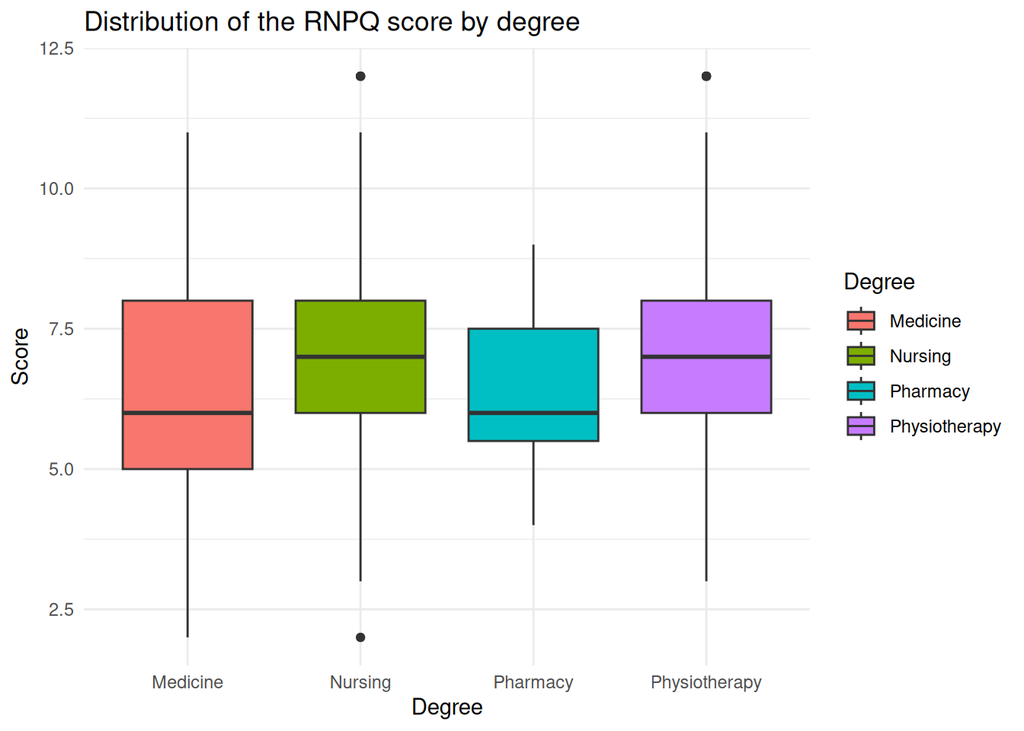

```r
df |>
    ggplot(aes(x = Degree, y = RNPQ, fill = Degree)) +
    geom_boxplot() +
    labs(title = "Distribution of the RNPQ score by degree",
         x = "Degree",
         y = "Score") +
    theme_minimal()
```

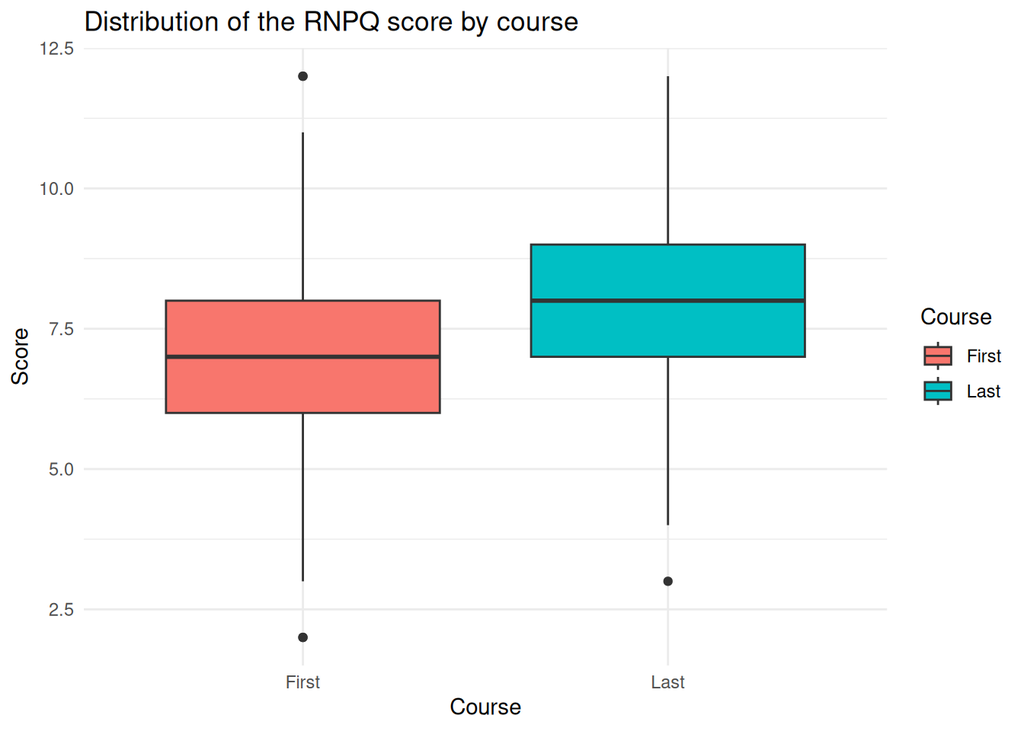

```r
df |>
    ggplot(aes(x = Course, y = RNPQ, fill = Course)) +
    geom_boxplot() +
    labs(title = "Distribution of the RNPQ score by course",
         x = "Course",
         y = "Score") +
    theme_minimal()
```

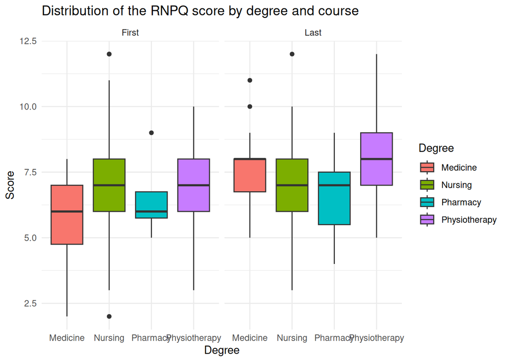

```r
df |>
    ggplot(aes(x = Degree, y = RNPQ, fill = Degree)) +
    geom_boxplot() +
    labs(title = "Distribution of the RNPQ score by degree and course",
         x = "Degree",
         y = "Score") +
    facet_grid(. ~ Course) +
    theme_minimal()
```

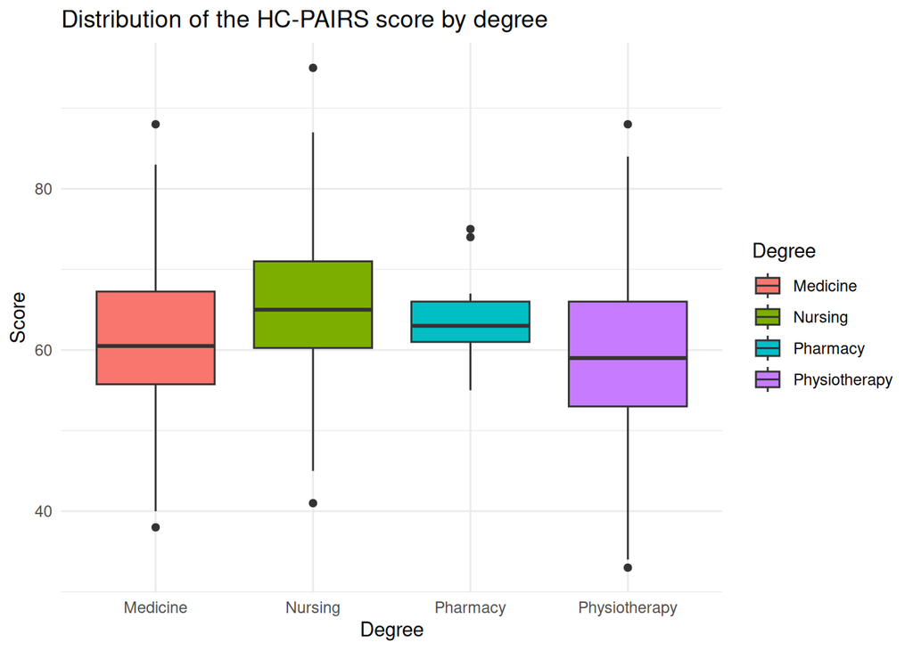

```r
df |>
    ggplot(aes(x = Degree, y = HC_PAIRS, fill = Degree)) +
    geom_boxplot() +
    labs(title = "Distribution of the HC-PAIRS score by degree",
         x = "Degree",
         y = "Score") +
    theme_minimal()
```

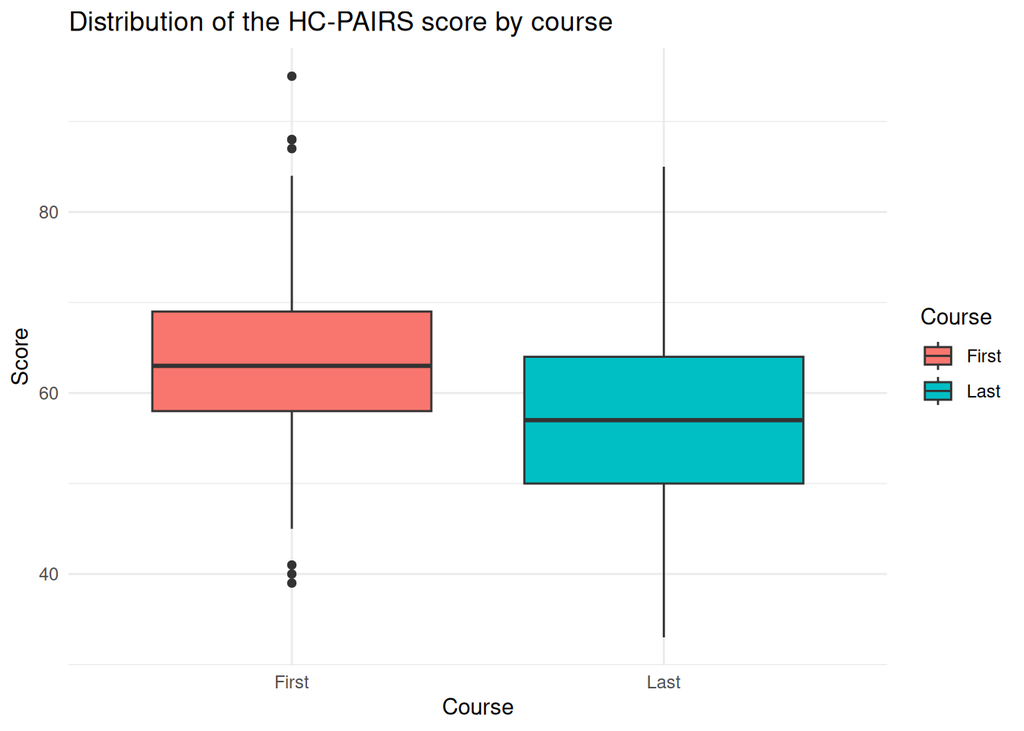

```r
df |>
    ggplot(aes(x = Course, y = HC_PAIRS, fill = Course)) +
    geom_boxplot() +
    labs(title = "Distribution of the HC-PAIRS score by course",
         x = "Course",
         y = "Score") +
    theme_minimal()
```

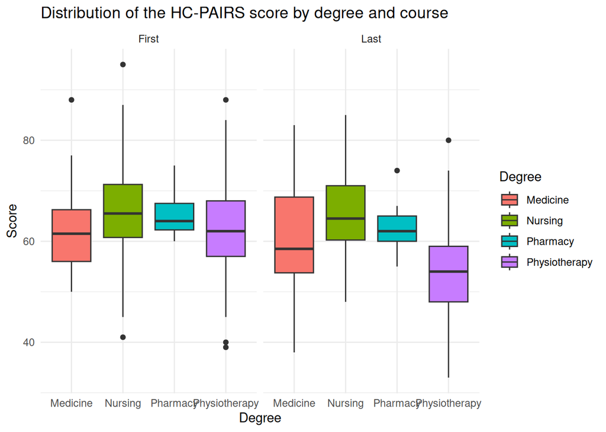

```r
df |>
    ggplot(aes(x = Degree, y = HC_PAIRS, fill = Degree)) +
    geom_boxplot() +
    labs(title = "Distribution of the HC-PAIRS score by degree and course",
         x = "Degree",
         y = "Score") +
    facet_grid(. ~ Course) +
    theme_minimal()
```

### Barplot

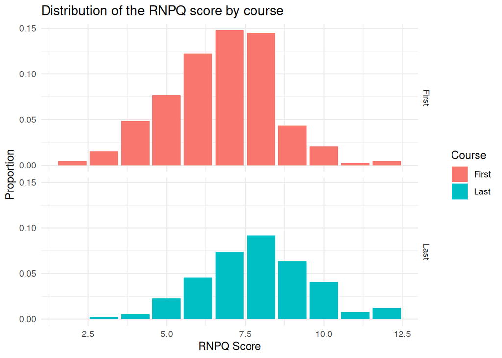

```r
df |>
    ggplot(aes(x = RNPQ, fill = Course)) +
    geom_bar(aes(y = ..count../sum(..count..))) +
    labs(title = "Distribution of the RNPQ score by course",
         x = "RNPQ Score",
         y = "Proportion") +
    facet_grid(Course ~ .) +
    theme_minimal()
```

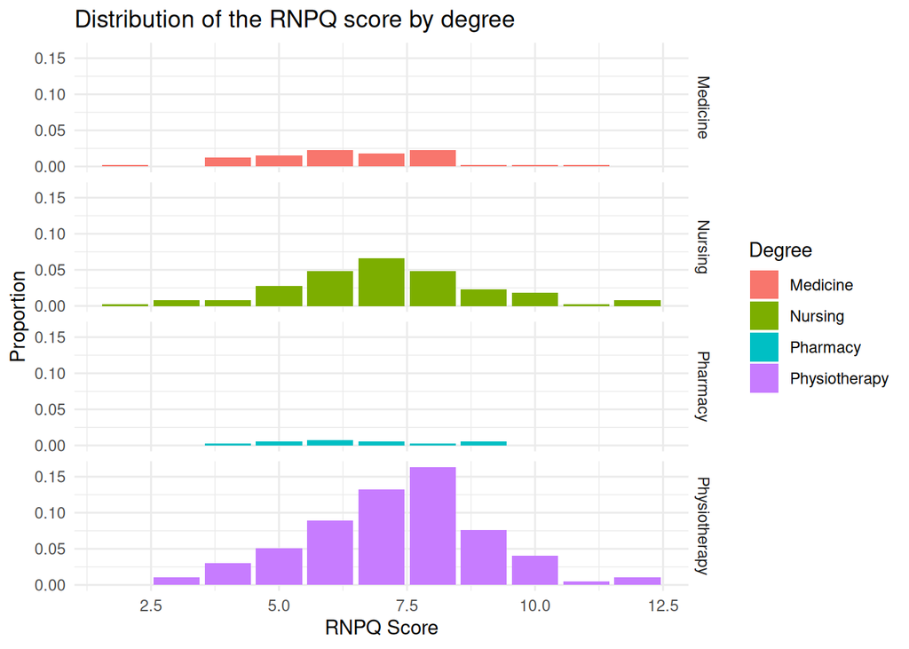

```r
df |>
    ggplot(aes(x = RNPQ, fill = Degree)) +
    geom_bar(aes(y = ..count../sum(..count..))) +
    labs(title = "Distribution of the RNPQ score by degree",
         x = "RNPQ Score",
         y = "Proportion") +
    facet_grid(Degree ~ .) +
    theme_minimal()
```

### Histogram

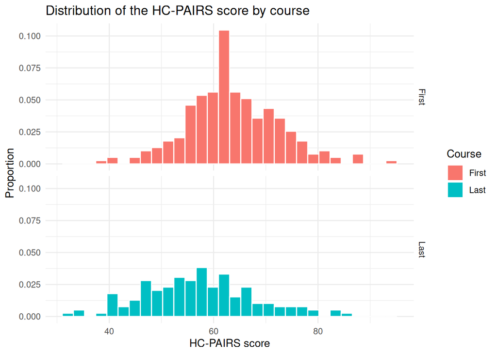

```r
df |>
    ggplot(aes(x = HC_PAIRS, fill = Course)) +
    geom_histogram(aes(y = ..count../sum(..count..)), color = "white") +
    labs(title = "Distribution of the HC-PAIRS score by course",
         x = "HC-PAIRS score",
         y = "Proportion") +
    facet_grid(Course ~ .) +
    theme_minimal()
```

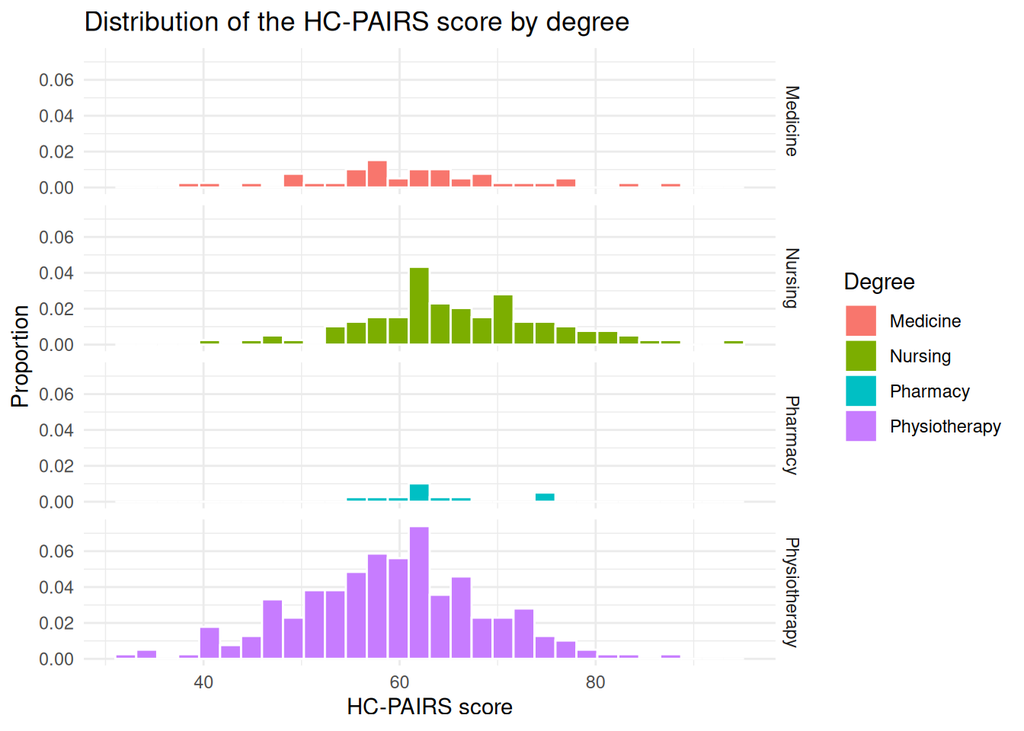

```r
df |>
    ggplot(aes(x = HC_PAIRS, fill = Degree)) +
    geom_histogram(aes(y = ..count../sum(..count..)), color = "white") +
    labs(title = "Distribution of the HC-PAIRS score by degree",
         x = "HC-PAIRS score",
         y = "Proportion") +
    facet_grid(Degree ~ .) +
    theme_minimal()
```

### Means plot

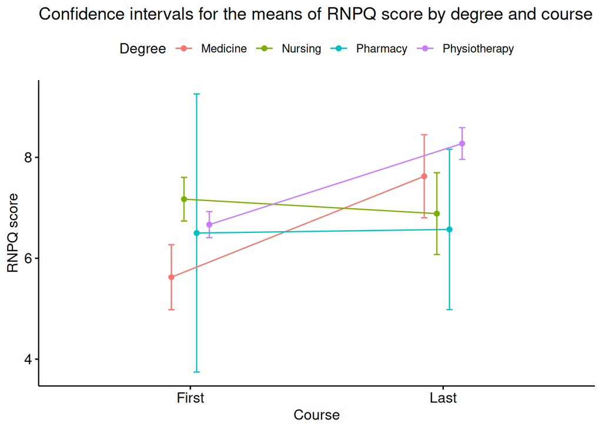

```r
ggline(df, x = "Course", y = "RNPQ", color = "Degree", add = c("mean_ci"), position = position_dodge(0.2), xlab = "Course", ylab = "RNPQ score", main = "Confidence intervals for the means of RNPQ score by degree and course", legend = "top")
```

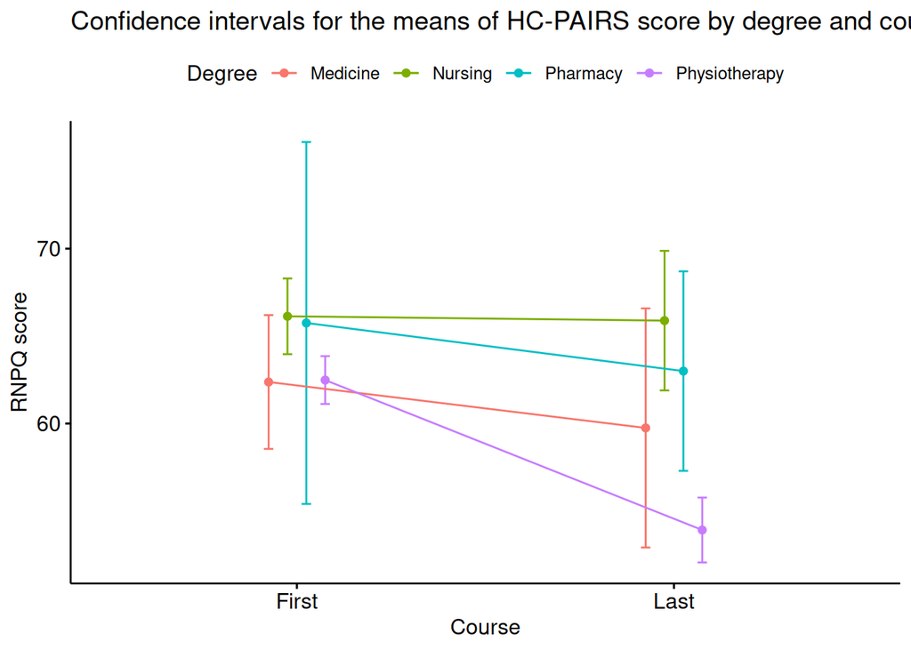

```r
ggline(df, x = "Course", y = "HC_PAIRS", color = "Degree", add = c("mean_ci"), position = position_dodge(0.2), xlab = "Course", ylab = "RNPQ score", main = "Confidence intervals for the means of HC-PAIRS score by degree and course", legend = "top")
```

**Caution**

It looks that the pain knowledge decreases in the fourth year of Nursing degree, that is very weird. Check the data.

## Comparison of RNPQ scores

### Normality test

```r
df |>
    group_by(Degree) |>
    do(tidy(shapiro.test(.$RNPQ))) |>
    kable()
```

| Degree | statistic | p.value | method |
| --- | --- | --- | --- |
| Medicine | 0.9633218 | 0.2172098 | Shapiro-Wilk normality test |
| Nursing | 0.9657976 | 0.0095865 | Shapiro-Wilk normality test |
| Pharmacy | 0.9418243 | 0.5421766 | Shapiro-Wilk normality test |
| Physiotherapy | 0.9640177 | 0.0000101 | Shapiro-Wilk normality test |

The distribution of the scores of the RNPQ questionnaire is not normal in the Physiotherapy and Nursing (p-value < 0.05).

```r
df |>
    group_by(Course) |>
    do(tidy(shapiro.test(.$RNPQ))) |>
    kable()
```

| Course | statistic | p.value | method |
| --- | --- | --- | --- |
| First | 0.9646175 | 0.0000083 | Shapiro-Wilk normality test |
| Last | 0.9672235 | 0.0015932 | Shapiro-Wilk normality test |

The distribution of the scores of the RNPQ questionnaire is not normal in the first and the last years (p-value < 0.05).

```r
df |>
    group_by(Degree, Course) |>
    do(tidy(shapiro.test(.$RNPQ))) |>
    kable()
```

| Degree | Course | statistic | p.value | method |
| --- | --- | --- | --- | --- |
| Medicine | First | 0.9417633 | 0.1785573 | Shapiro-Wilk normality test |
| Medicine | Last | 0.9404449 | 0.3544989 | Shapiro-Wilk normality test |
| Nursing | First | 0.9650159 | 0.0342188 | Shapiro-Wilk normality test |
| Nursing | Last | 0.9605245 | 0.4019619 | Shapiro-Wilk normality test |
| Pharmacy | First | 0.8397017 | 0.1945345 | Shapiro-Wilk normality test |
| Pharmacy | Last | 0.9796184 | 0.9576651 | Shapiro-Wilk normality test |
| Physiotherapy | First | 0.9446264 | 0.0000177 | Shapiro-Wilk normality test |
| Physiotherapy | Last | 0.9532697 | 0.0019120 | Shapiro-Wilk normality test |

### Homoscedasticity test

```r
leveneTest(RNPQ ~ Degree * Course, data = df) |>
    tidy() |>
    kable()
```

| statistic | p.value | df | df.residual |
| --- | --- | --- | --- |
| 0.4624523 | 0.8614977 | 7 | 384 |

The variances of the scores of the RNPQ questionnaire are homogeneous in all the degree-course groups (p-value > 0.05).

### ANOVA

```r
anova <- aov(RNPQ ~ Degree * Course, data = df)
# Use the type III sum of squares as the groups are unbalanced.
Anova(anova, type = "III") |>
    tidy() |>
    kable()
```

| term | sumsq | df | statistic | p.value |
| --- | --- | --- | --- | --- |
| (Intercept) | 759.37500 | 1 | 274.471947 | 0.0000000 |
| Degree | 44.84062 | 3 | 5.402466 | 0.0011914 |
| Course | 38.40000 | 1 | 13.879470 | 0.0002242 |
| Degree:Course | 61.66657 | 3 | 7.429681 | 0.0000755 |
| Residuals | 1062.40366 | 384 | NA | NA |

The ANOVA test shows both, the degree and the course, have a statistically significant effect on the scores of the RNPQ questionnaire, and also the interaction between the degree and the course has a statistically significant effect (p-value < 0.05).

**Caution**

You should not trust the ANOVA results because the normality assumption is not met in some groups.

### Mann-Whitney test

As the normality assumption is not met the courses, we will use the Mann-Whitney test to compare the scores of the RNPQ questionnaire between the couses.

```r
wilcox.test(RNPQ ~ Course, data = df, alternative = "less") |>
    tidy() |>
    kable()
```

| statistic | p.value | method | alternative |
| --- | --- | --- | --- |
| 11516 | 0 | Wilcoxon rank sum test with continuity correction | less |

The Mann-Whitney test shows a statistically significant difference between the first and the last course (p-value < 0.05).

### Kruksal-Wallis test

As the normality assumption is not met in some groups, we will use the Kruksal-Wallis test to compare the scores of the RNPQ questionnaire among the Degree-Course groups .

```r
kruskal.test(RNPQ ~ Degree_Course, data = df) |>
    tidy() |>
    kable()
```

| statistic | p.value | parameter | method |
| --- | --- | --- | --- |
| 67.07969 | 0 | 7 | Kruskal-Wallis rank sum test |

The Kruksal-Wallis test shows a statistically significant difference between the degrees (p-value < 0.05).

### Post-hoc test

```r
df |>
    dunn_test(RNPQ ~ Degree_Course, p.adjust.method = "BH") |>
    arrange(p.adj) |>
    kable()
```

| .y. | group1 | group2 | n1 | n2 | statistic | p | p.adj | p.adj.signif |
| --- | --- | --- | --- | --- | --- | --- | --- | --- |
| RNPQ | Physiotherapy.First | Physiotherapy.Last | 144 | 95 | 6.6642687 | 0.0000000 | 0.0000000 | **** |
| RNPQ | Medicine.First | Physiotherapy.Last | 24 | 95 | 6.4155263 | 0.0000000 | 0.0000000 | **** |
| RNPQ | Nursing.First | Physiotherapy.Last | 76 | 95 | 4.0784991 | 0.0000453 | 0.0004231 | *** |
| RNPQ | Nursing.Last | Physiotherapy.Last | 26 | 95 | 3.7761009 | 0.0001593 | 0.0011151 | ** |
| RNPQ | Medicine.First | Nursing.First | 24 | 76 | 3.5789972 | 0.0003449 | 0.0019315 | ** |
| RNPQ | Medicine.First | Medicine.Last | 24 | 16 | 3.3665264 | 0.0007612 | 0.0035523 | ** |
| RNPQ | Medicine.First | Physiotherapy.First | 24 | 144 | 2.6524678 | 0.0079906 | 0.0319623 | * |
| RNPQ | Pharmacy.Last | Physiotherapy.Last | 7 | 95 | 2.4014047 | 0.0163323 | 0.0571629 | ns |
| RNPQ | Medicine.First | Nursing.Last | 24 | 26 | 2.2252692 | 0.0260632 | 0.0810854 | ns |
| RNPQ | Pharmacy.First | Physiotherapy.Last | 4 | 95 | 2.0958103 | 0.0360990 | 0.1010773 | ns |
| RNPQ | Physiotherapy.First | Medicine.Last | 144 | 16 | 1.9039221 | 0.0569203 | 0.1448881 | ns |
| RNPQ | Nursing.First | Physiotherapy.First | 76 | 144 | -1.7857981 | 0.0741320 | 0.1729746 | ns |
| RNPQ | Medicine.Last | Nursing.Last | 16 | 26 | -1.4371185 | 0.1506843 | 0.3212392 | ns |
| RNPQ | Medicine.Last | Physiotherapy.Last | 16 | 95 | 1.4029907 | 0.1606196 | 0.3212392 | ns |
| RNPQ | Medicine.First | Pharmacy.Last | 24 | 7 | 1.2226078 | 0.2214778 | 0.3647870 | ns |
| RNPQ | Pharmacy.First | Medicine.Last | 4 | 16 | 1.2353887 | 0.2166859 | 0.3647870 | ns |
| RNPQ | Medicine.Last | Pharmacy.Last | 16 | 7 | -1.2387481 | 0.2154388 | 0.3647870 | ns |
| RNPQ | Nursing.First | Medicine.Last | 76 | 16 | 0.9035570 | 0.3662303 | 0.5397079 | ns |
| RNPQ | Nursing.First | Nursing.Last | 76 | 26 | -0.9159552 | 0.3596904 | 0.5397079 | ns |
| RNPQ | Nursing.First | Pharmacy.First | 76 | 4 | -0.8617552 | 0.3888223 | 0.5443512 | ns |
| RNPQ | Nursing.First | Pharmacy.Last | 76 | 7 | -0.7919827 | 0.4283707 | 0.5711610 | ns |
| RNPQ | Medicine.First | Pharmacy.First | 24 | 4 | 0.7331355 | 0.4634758 | 0.5898783 | ns |
| RNPQ | Pharmacy.First | Nursing.Last | 4 | 26 | 0.4356226 | 0.6631106 | 0.8072650 | ns |
| RNPQ | Pharmacy.First | Physiotherapy.First | 4 | 144 | 0.3726118 | 0.7094374 | 0.8276769 | ns |
| RNPQ | Pharmacy.First | Pharmacy.Last | 4 | 7 | 0.2062083 | 0.8366282 | 0.8676145 | ns |
| RNPQ | Physiotherapy.First | Nursing.Last | 144 | 26 | 0.2116091 | 0.8324120 | 0.8676145 | ns |
| RNPQ | Nursing.Last | Pharmacy.Last | 26 | 7 | -0.2459259 | 0.8057396 | 0.8676145 | ns |
| RNPQ | Physiotherapy.First | Pharmacy.Last | 144 | 7 | -0.1540605 | 0.8775621 | 0.8775621 | ns |

According to the Dunn test, there are statistically significant differences between:

- First course of Physiotherapy and last course of Physiotherapy (p-value < 0.01).
- Firs course of Medicine and last course of Physiotherapy (p-value < 0.01).
- First course of Nursing and last course of Physiotherapy (p-value < 0.01).
- Last course of Nursing and last course of Physiotherapy (p-value < 0.01).- First course of Medicine and first course of Nursing (p-value < 0.01).
- First course of Medicine and last course of Medicine (p-value < 0.01).
- First course of Medicine and first course of Physiotherapy (p-value < 0.05).

### Two factors ANOVA for ranks

As the Kruskal-Wallis test can not be used for two factors, we can not study the interaction between the degree and the course. However, we can use the two factors ANOVA for ranks to study the effect of the degree and the course on the scores of the RNPQ questionnaire, and the interaction between the degree and the course.

```r
anova_ranks <- aov(rank(RNPQ) ~ Degree * Course, data = df)
# Use the type III sum of squares as the groups are unbalanced.
Anova(anova_ranks, type = "III") |>
    tidy() |>
    kable()
```

| term | sumsq | df | statistic | p.value |
| --- | --- | --- | --- | --- |
| (Intercept) | 258233.8 | 1 | 24.625322 | 0.0000010 |
| Degree | 163389.5 | 3 | 5.193638 | 0.0015827 |
| Course | 140892.6 | 1 | 13.435601 | 0.0002816 |
| Degree:Course | 246541.0 | 3 | 7.836763 | 0.0000434 |
| Residuals | 4026821.1 | 384 | NA | NA |

The two factors ANOVA for ranks shows both, the degree and the course, have a statistically significant effect on the scores of the RNPQ questionnaire, and also the interaction between the degree and the course has a statistically significant effect (p-value < 0.05).

### Post-hoc test

```r
library(emmeans)
emmeans(anova_ranks, ~ Course | Degree) |>
    pairs() |>
    test(joint = TRUE) |>
    kable()
```

| Degree | df1 | df2 | F.ratio | p.value |
| --- | --- | --- | --- | --- |
| Medicine | 1 | 384 | 13.436 | 0.0002816 |
| Nursing | 1 | 384 | 0.995 | 0.3192526 |
| Pharmacy | 1 | 384 | 0.050 | 0.8224731 |
| Physiotherapy | 1 | 384 | 52.650 | 0.0000000 |

The course is significant for Medicine and Physiotherapy degrees (p-value < 0.01).

```r
library(emmeans)
emmeans(anova_ranks, ~ Degree | Course) |>
    pairs() |>
    test(joint = TRUE) |>
    kable()
```

|  | Course | df1 | df2 | F.ratio | p.value | note |
| --- | --- | --- | --- | --- | --- | --- |
| 1 | First | 3 | 384 | 5.194 | 0.0015827 | d |
| 7 | Last | 3 | 384 | 7.289 | 0.0000915 | d |

There degree is significant for the first and the last course (p-value < 0.01).

## Comparison of HC-PAIRS scores

### Normality test

```r
df |>
    group_by(Degree) |>
    do(tidy(shapiro.test(.$HC_PAIRS))) |>
    kable()
```

| Degree | statistic | p.value | method |
| --- | --- | --- | --- |
| Medicine | 0.9837228 | 0.8233032 | Shapiro-Wilk normality test |
| Nursing | 0.9911599 | 0.7461934 | Shapiro-Wilk normality test |
| Pharmacy | 0.9236546 | 0.3502634 | Shapiro-Wilk normality test |
| Physiotherapy | 0.9966406 | 0.8928924 | Shapiro-Wilk normality test |

The distribution of the scores of the HC-PAIRS questionnaire is normal in all the degrees (p-value > 0.05).

```r
df |>
    group_by(Course) |>
    do(tidy(shapiro.test(.$HC_PAIRS))) |>
    kable()
```

| Course | statistic | p.value | method |
| --- | --- | --- | --- |
| First | 0.9896352 | 0.0733262 | Shapiro-Wilk normality test |
| Last | 0.9897267 | 0.3727331 | Shapiro-Wilk normality test |

The distribution of the scores of the HC-PAIRS questionnaire is normal in both courses (p-value > 0.05).

```r
df |>
    group_by(Degree, Course) |>
    do(tidy(shapiro.test(.$HC_PAIRS))) |>
    kable()
```

| Degree | Course | statistic | p.value | method |
| --- | --- | --- | --- | --- |
| Medicine | First | 0.9355330 | 0.1296360 | Shapiro-Wilk normality test |
| Medicine | Last | 0.9702828 | 0.8431687 | Shapiro-Wilk normality test |
| Nursing | First | 0.9842407 | 0.4681812 | Shapiro-Wilk normality test |
| Nursing | Last | 0.9721435 | 0.6794428 | Shapiro-Wilk normality test |
| Pharmacy | First | 0.8934473 | 0.3992450 | Shapiro-Wilk normality test |
| Pharmacy | Last | 0.9487094 | 0.7179366 | Shapiro-Wilk normality test |
| Physiotherapy | First | 0.9926727 | 0.6699861 | Shapiro-Wilk normality test |
| Physiotherapy | Last | 0.9910846 | 0.7800416 | Shapiro-Wilk normality test |

The distribution of the scores of the HC-PAIRS questionnaire is normal in all the degree-course groups (p-value > 0.05).

### Homoscedasticity test

```r
library(car)
leveneTest(HC_PAIRS ~ Degree * Course, data = df) |>
    tidy() |>
    kable()
```

| statistic | p.value | df | df.residual |
| --- | --- | --- | --- |
| 1.192472 | 0.3059348 | 7 | 384 |

The variances of the scores of the HC-PAIRS questionnaire are homogeneous in all the degree-course groups (p-value > 0.05).

### ANOVA

```r
anova <- aov(HC_PAIRS ~ Degree * Course, data = df)

anova |>
    tidy() |>
    kable()
```

| term | df | sumsq | meansq | statistic | p.value |
| --- | --- | --- | --- | --- | --- |
| Degree | 3 | 3577.624 | 1192.54134 | 14.525652 | 0.0000000 |
| Course | 1 | 3135.487 | 3135.48741 | 38.191547 | 0.0000000 |
| Degree:Course | 3 | 1155.285 | 385.09505 | 4.690619 | 0.0031341 |
| Residuals | 384 | 31526.012 | 82.09899 | NA | NA |

The ANOVA test shows both, the degree and the course, have a statistically significant effect on the scores of the HC-PAIRS questionnaire, and also the interaction between the degree and the course has a statistically significant effect (p-value < 0.01).

### Post-hoc test

```r
TukeyHSD(anova) |>
    tidy() |>
    arrange(term, adj.p.value) |>
    kable()
```

| term | contrast | null.value | estimate | conf.low | conf.high | adj.p.value |
| --- | --- | --- | --- | --- | --- | --- |
| Course | Last-First | 0 | -5.7906125 | -7.657095 | -3.9241300 | 0.0000000 |
| Degree | Physiotherapy-Nursing | 0 | -6.9891295 | -9.754287 | -4.2239719 | 0.0000000 |
| Degree | Nursing-Medicine | 0 | 4.7436275 | 0.381927 | 9.1053279 | 0.0269342 |
| Degree | Physiotherapy-Pharmacy | 0 | -4.9205021 | -12.130190 | 2.2891856 | 0.2938704 |
| Degree | Physiotherapy-Medicine | 0 | -2.2455021 | -6.239565 | 1.7485608 | 0.4685663 |
| Degree | Pharmacy-Medicine | 0 | 2.6750000 | -5.284770 | 10.6347695 | 0.8218089 |
| Degree | Pharmacy-Nursing | 0 | -2.0686275 | -9.488297 | 5.3510416 | 0.8893498 |
| Degree:Course | Physiotherapy:Last-Nursing:First | 0 | -12.2157895 | -16.465646 | -7.9659335 | 0.0000000 |
| Degree:Course | Physiotherapy:Last-Physiotherapy:First | 0 | -8.5703216 | -12.220387 | -4.9202561 | 0.0000000 |
| Degree:Course | Physiotherapy:Last-Nursing:Last | 0 | -11.9688259 | -18.080905 | -5.8567468 | 0.0000002 |
| Degree:Course | Physiotherapy:Last-Medicine:First | 0 | -8.4592105 | -14.768069 | -2.1503516 | 0.0013693 |
| Degree:Course | Physiotherapy:First-Nursing:First | 0 | -3.6454678 | -7.560795 | 0.2698593 | 0.0889100 |
| Degree:Course | Medicine:Last-Nursing:First | 0 | -6.3815789 | -13.977350 | 1.2141924 | 0.1738801 |
| Degree:Course | Physiotherapy:Last-Pharmacy:Last | 0 | -9.0842105 | -19.899397 | 1.7309762 | 0.1741160 |
| Degree:Course | Physiotherapy:Last-Pharmacy:First | 0 | -11.8342105 | -25.929388 | 2.2609672 | 0.1745384 |
| Degree:Course | Physiotherapy:Last-Medicine:Last | 0 | -5.8342105 | -13.296712 | 1.6282913 | 0.2528134 |
| Degree:Course | Nursing:Last-Medicine:Last | 0 | 6.1346154 | -2.639892 | 14.9091226 | 0.3969726 |
| Degree:Course | Nursing:First-Medicine:First | 0 | 3.7565789 | -2.709371 | 10.2225289 | 0.6403800 |
| Degree:Course | Nursing:Last-Physiotherapy:First | 0 | 3.3985043 | -2.485884 | 9.2828922 | 0.6474266 |
| Degree:Course | Nursing:Last-Medicine:First | 0 | 3.5096154 | -4.307337 | 11.3265677 | 0.8710790 |
| Degree:Course | Medicine:Last-Pharmacy:First | 0 | -6.0000000 | -21.437244 | 9.4372440 | 0.9360228 |
| Degree:Course | Medicine:Last-Physiotherapy:First | 0 | -2.7361111 | -10.013298 | 4.5410755 | 0.9461159 |
| Degree:Course | Medicine:Last-Medicine:First | 0 | -2.6250000 | -11.537697 | 6.2876970 | 0.9861768 |
| Degree:Course | Pharmacy:Last-Nursing:First | 0 | -3.1315789 | -14.039148 | 7.7759905 | 0.9881086 |
| Degree:Course | Pharmacy:Last-Medicine:Last | 0 | 3.2500000 | -9.264101 | 15.7641012 | 0.9934981 |
| Degree:Course | Pharmacy:Last-Nursing:Last | 0 | -2.8846154 | -14.643497 | 8.8742666 | 0.9954231 |
| Degree:Course | Physiotherapy:First-Pharmacy:First | 0 | -3.2638889 | -17.261837 | 10.7340590 | 0.9966660 |
| Degree:Course | Pharmacy:First-Medicine:First | 0 | 3.3750000 | -11.538795 | 18.2887946 | 0.9972382 |
| Degree:Course | Pharmacy:Last-Pharmacy:First | 0 | -2.7500000 | -20.058606 | 14.5586057 | 0.9997235 |
| Degree:Course | Pharmacy:Last-Medicine:First | 0 | 0.6250000 | -11.237356 | 12.4873563 | 0.9999999 |
| Degree:Course | Pharmacy:Last-Physiotherapy:First | 0 | 0.5138889 | -10.174272 | 11.2020493 | 0.9999999 |
| Degree:Course | Nursing:Last-Nursing:First | 0 | -0.2469636 | -6.521063 | 6.0271355 | 1.0000000 |
| Degree:Course | Pharmacy:First-Nursing:First | 0 | -0.3815789 | -14.547766 | 13.7846077 | 1.0000000 |
| Degree:Course | Physiotherapy:First-Medicine:First | 0 | 0.1111111 | -5.977420 | 6.1996422 | 1.0000000 |
| Degree:Course | Nursing:Last-Pharmacy:First | 0 | 0.1346154 | -14.697009 | 14.9662397 | 1.0000000 |

For the comparison among degrees, there are statistically significant differences between:

- Nursing and Physiotherapy (p-value < 0.01). The mean of Physiotherapy is between 4.22 and 9.74 points smaller.
- Nursing and Medicine (p-value < 0.05). The mean of Medicine is between 0.38 and 9.1 points smaller.

For the comparison between courses, there is a statistically significant difference between the first and the fourth course (p-value < 0.01). The mean of the fourth course is between 3.92 and 7.66 points smaller.

For the comparison among degree-course groups, there are statistically significant differences between:

- First course of Nursing and last course of Physiotherapy (p-value < 0.01). The mean of the last course of Physiotherapy is between 7.97 and 16.47 points smaller.
- First course of Physiotherapy and last course of Physiotherapy (p-value < 0.01). The mean of the last course of Physiotherapy is between 4.92 and 12.22 points smaller.
- Last course of Nursing and last course of Physiotherapy (p-value < 0.01). The mean of the last course of Physiotherapy is between 5.86 and 18.08 points smaller.
- First course of Medicine and last course of Physiotherapy (p-value < 0.01). The mean of the last course of Physiotherapy is between 2.15 and 14.77 points smaller.

There are no statistically significant differences between the other groups, in particular, between the means of the first and last courses of Nursing, Pharmacy and Medicine.